# Project: Investigate a Dataset - [TMDb Movies]

## Introduction

> **Name: Ikechukwu Chilaka**

> **Date: May 29, 2022**

> Investigating TMDB dataset that contains information of over 10k+ movies collected from 1960 to 2015

### Dataset Description

> This data set contains information about 10,000 movies collected from The Movie Database (TMDb) from 1960 to 2015, The dataset has 21 columns and 10866 rows in all. The columns include:

> **'id' and 'imdb_id':** which are unique identifiers of the movies,

> **'popularity':** how popular the movie is amongst viewers; a metric that boosts search results [https://developers.themoviedb.org/3/getting-started/popularity]

> **'budget' and 'revenue':** the budjet and income without accounting for inflation

> **'original_title'and 'cast':** the title of the movie and the lead actor(s)

> **'homepage':** website to see the movies landing page,

> **'director', 'genres', 'production_companies':** info on the name of the directors, the movie genre, and production companies

> **'tagline':** short text which serves to clarify an idea for, or is designed with a form of, dramatic effect.

> **'keywords':** keywords associated with the movie to allow for easy search,

> **'overview':** brief plot summary

> **'release_year':** year of movie release, **'release_date':** date of release **'runtime':** duration of movie in mins

> **'budget_adj', and 'revenue_adj':** show the budget and revenue of the associated movie in terms of 2010 dollars, accounting for inflation over time.

> **vote_count** represents the number of users who voted while **vote_average:** what the voters voted on a scale on 1-10 [https://help.imdb.com/article/imdb/track-movies-tv/ratings-faq/G67Y87TFYYP6TWAV#]

### Question(s) for Analysis

**Primary question: What properties of the movie data given affects the income made from the movie?**

> **Does the length of the movie affect the movie's profitability?**

Producers would need this to encourage screen writers to write more scenes or not

> **Do movies with better more user engagement mean more income?**

a.What genre are these movies?

b.The day which the movie is released (weekend or weekday) could also affect views

```python
#Set the working environment.

import pandas as pd
import numpy as np
import matplotlib.pyplot as plt
%matplotlib inline
import seaborn as sns
sns.set_style('darkgrid')
```

```python
# Upgrading pandas to use dataframe.explode() function.
!pip install --upgrade pandas==0.25.0
```

## Data Wrangling

> **I will check the datasets and figure out what needs cleaning and trimming**

```python
# Load the data and view the first five rows
df = pd.read_csv('tmdb-movies.csv', sep =",")
df.head()
```

|  | id | imdb_id | popularity | budget | revenue | original_title | cast | homepage | director | tagline | ... | overview | runtime | genres | production_companies | release_date | vote_count | vote_average | release_year | budget_adj | revenue_adj |
| --- | --- | --- | --- | --- | --- | --- | --- | --- | --- | --- | --- | --- | --- | --- | --- | --- | --- | --- | --- | --- | --- |
| 0 | 135397 | tt0369610 | 32.985763 | 150000000 | 1513528810 | Jurassic World | Chris Pratt\|Bryce Dallas Howard\|Irrfan Khan\|Vi... | http://www.jurassicworld.com/ | Colin Trevorrow | The park is open. | ... | Twenty-two years after the events of Jurassic ... | 124 | Action\|Adventure\|Science Fiction\|Thriller | Universal Studios\|Amblin Entertainment\|Legenda... | 6/9/15 | 5562 | 6.5 | 2015 | 1.379999e+08 | 1.392446e+09 |
| 1 | 76341 | tt1392190 | 28.419936 | 150000000 | 378436354 | Mad Max: Fury Road | Tom Hardy\|Charlize Theron\|Hugh Keays-Byrne\|Nic... | http://www.madmaxmovie.com/ | George Miller | What a Lovely Day. | ... | An apocalyptic story set in the furthest reach... | 120 | Action\|Adventure\|Science Fiction\|Thriller | Village Roadshow Pictures\|Kennedy Miller Produ... | 5/13/15 | 6185 | 7.1 | 2015 | 1.379999e+08 | 3.481613e+08 |
| 2 | 262500 | tt2908446 | 13.112507 | 110000000 | 295238201 | Insurgent | Shailene Woodley\|Theo James\|Kate Winslet\|Ansel... | http://www.thedivergentseries.movie/#insurgent | Robert Schwentke | One Choice Can Destroy You | ... | Beatrice Prior must confront her inner demons ... | 119 | Adventure\|Science Fiction\|Thriller | Summit Entertainment\|Mandeville Films\|Red Wago... | 3/18/15 | 2480 | 6.3 | 2015 | 1.012000e+08 | 2.716190e+08 |
| 3 | 140607 | tt2488496 | 11.173104 | 200000000 | 2068178225 | Star Wars: The Force Awakens | Harrison Ford\|Mark Hamill\|Carrie Fisher\|Adam D... | http://www.starwars.com/films/star-wars-episod... | J.J. Abrams | Every generation has a story. | ... | Thirty years after defeating the Galactic Empi... | 136 | Action\|Adventure\|Science Fiction\|Fantasy | Lucasfilm\|Truenorth Productions\|Bad Robot | 12/15/15 | 5292 | 7.5 | 2015 | 1.839999e+08 | 1.902723e+09 |
| 4 | 168259 | tt2820852 | 9.335014 | 190000000 | 1506249360 | Furious 7 | Vin Diesel\|Paul Walker\|Jason Statham\|Michelle ... | http://www.furious7.com/ | James Wan | Vengeance Hits Home | ... | Deckard Shaw seeks revenge against Dominic Tor... | 137 | Action\|Crime\|Thriller | Universal Pictures\|Original Film\|Media Rights ... | 4/1/15 | 2947 | 7.3 | 2015 | 1.747999e+08 | 1.385749e+09 |

5 rows × 21 columns

I will view the basic info about the data

```python
df.info()
```

```
<class 'pandas.core.frame.DataFrame'>
RangeIndex: 10866 entries, 0 to 10865
Data columns (total 21 columns):
id                      10866 non-null int64
imdb_id                 10856 non-null object
popularity              10866 non-null float64
budget                  10866 non-null int64
revenue                 10866 non-null int64
original_title          10866 non-null object
cast                    10790 non-null object
homepage                2936 non-null object
director                10822 non-null object
tagline                 8042 non-null object
keywords                9373 non-null object
overview                10862 non-null object
runtime                 10866 non-null int64
genres                  10843 non-null object
production_companies    9836 non-null object
release_date            10866 non-null object
vote_count              10866 non-null int64
vote_average            10866 non-null float64
release_year            10866 non-null int64
budget_adj              10866 non-null float64
revenue_adj             10866 non-null float64
dtypes: float64(4), int64(6), object(11)
memory usage: 1.7+ MB
```

I have seen that release date is not in datetime, I will have to convert it. Also observed null values in the columns

```python
#Do the movie entries have unique IDs?
df['id'].nunique()
```

```
10865
```

One row repeats itself

Do the movie entries have unique database IDs?

```python
df['imdb_id'].nunique()
```

```
10855
```

```python
#viewing summary statistics
df.describe()
```

|  | id | popularity | budget | revenue | runtime | vote_count | vote_average | release_year | budget_adj | revenue_adj |
| --- | --- | --- | --- | --- | --- | --- | --- | --- | --- | --- |
| count | 10866.000000 | 10866.000000 | 1.086600e+04 | 1.086600e+04 | 10866.000000 | 10866.000000 | 10866.000000 | 10866.000000 | 1.086600e+04 | 1.086600e+04 |
| mean | 66064.177434 | 0.646441 | 1.462570e+07 | 3.982332e+07 | 102.070863 | 217.389748 | 5.974922 | 2001.322658 | 1.755104e+07 | 5.136436e+07 |
| std | 92130.136561 | 1.000185 | 3.091321e+07 | 1.170035e+08 | 31.381405 | 575.619058 | 0.935142 | 12.812941 | 3.430616e+07 | 1.446325e+08 |
| min | 5.000000 | 0.000065 | 0.000000e+00 | 0.000000e+00 | 0.000000 | 10.000000 | 1.500000 | 1960.000000 | 0.000000e+00 | 0.000000e+00 |
| 25% | 10596.250000 | 0.207583 | 0.000000e+00 | 0.000000e+00 | 90.000000 | 17.000000 | 5.400000 | 1995.000000 | 0.000000e+00 | 0.000000e+00 |
| 50% | 20669.000000 | 0.383856 | 0.000000e+00 | 0.000000e+00 | 99.000000 | 38.000000 | 6.000000 | 2006.000000 | 0.000000e+00 | 0.000000e+00 |
| 75% | 75610.000000 | 0.713817 | 1.500000e+07 | 2.400000e+07 | 111.000000 | 145.750000 | 6.600000 | 2011.000000 | 2.085325e+07 | 3.369710e+07 |
| max | 417859.000000 | 32.985763 | 4.250000e+08 | 2.781506e+09 | 900.000000 | 9767.000000 | 9.200000 | 2015.000000 | 4.250000e+08 | 2.827124e+09 |

Wow! looking at minimum value, runtime cannot be zero. It means there was no movie at all.

Why would movies have zero budget Could a movie make nothing as revenue?

Min and Max of vote_average is [1.5, 9.2]. It seems it is on a 10-scale

```python
#Find places where runtime is zero
zero_runtime = df[df.runtime == 0]
zero_runtime.shape[0]
```

```
31
```

There are 31 instances of zero runtime

```python
#See where fields are null
df.isnull().sum()
```

```
id                         0
imdb_id                   10
popularity                 0
budget                     0
revenue                    0
original_title             0
cast                      76
homepage                7930
director                  44
tagline                 2824
keywords                1493
overview                   4
runtime                    0
genres                    23
production_companies    1030
release_date               0
vote_count                 0
vote_average               0
release_year               0
budget_adj                 0
revenue_adj                0
dtype: int64
```

So many blank fields... Let me take a look

```python
df[df['production_companies'].isnull()]
```

|  | id | imdb_id | popularity | budget | revenue | original_title | cast | homepage | director | tagline | ... | overview | runtime | genres | production_companies | release_date | vote_count | vote_average | release_year | budget_adj | revenue_adj |
| --- | --- | --- | --- | --- | --- | --- | --- | --- | --- | --- | --- | --- | --- | --- | --- | --- | --- | --- | --- | --- | --- |
| 228 | 300792 | tt1618448 | 0.584363 | 0 | 0 | Racing Extinction | Elon Musk\|Jane Goodall\|Louie Psihoyos\|Leilani ... | http://www.racingextinction.com | Louie Psihoyos | It's better to light one candle than curse the... | ... | An unlikely team of activists and innovators h... | 90 | Adventure\|Documentary | NaN | 1/24/15 | 36 | 7.8 | 2015 | 0.000000e+00 | 0.000000e+00 |
| 259 | 360603 | tt5133572 | 0.476341 | 0 | 0 | Crown for Christmas | Danica McKellar\|Rupert Penry-Jones\|Ellie Botte... | NaN | Alex Zamm | NaN | ... | After getting fired from her job as a maid at ... | 84 | TV Movie | NaN | 11/27/15 | 10 | 7.6 | 2015 | 0.000000e+00 | 0.000000e+00 |
| 295 | 363483 | tt5133810 | 0.417191 | 0 | 0 | 12 Gifts of Christmas | Katrina Law\|Donna Mills\|Aaron O'Connell\|Melani... | NaN | Peter Sullivan | NaN | ... | When Anna Parisi, an unemployed fine arts pain... | 84 | Family\|TV Movie | NaN | 11/26/15 | 12 | 6.3 | 2015 | 0.000000e+00 | 0.000000e+00 |
| 298 | 354220 | tt3826866 | 0.370258 | 0 | 0 | The Girl in the Photographs | Kal Penn\|Claudia Lee\|Kenny Wormald\|Toby Heming... | NaN | Nick Simon | NaN | ... | Images coming from the crimes committed by a d... | 95 | Crime\|Horror\|Thriller | NaN | 9/14/15 | 10 | 4.7 | 2015 | 0.000000e+00 | 0.000000e+00 |
| 328 | 308457 | tt3090670 | 0.367617 | 0 | 0 | Advantageous | Jacqueline Kim\|James Urbaniak\|Freya Adams\|Ken ... | NaN | Jennifer Phang | NaN | ... | In a near-future city where soaring opulence o... | 92 | Science Fiction\|Drama\|Family | NaN | 6/23/15 | 29 | 6.4 | 2015 | 0.000000e+00 | 0.000000e+00 |
| 370 | 318279 | tt2545428 | 0.314199 | 0 | 2334228 | Meru | Conrad Anker\|Grace Chin\|Jimmy Chin\|Amee Hinkley | http://www.merufilm.com/ | Jimmy Chin\|Elizabeth Chai Vasarhelyi | NaN | ... | Meru is the electrifying story of three elite ... | 89 | Adventure\|Documentary | NaN | 1/25/15 | 42 | 6.9 | 2015 | 0.000000e+00 | 2.147489e+06 |
| 374 | 206197 | tt1015471 | 0.302474 | 0 | 0 | The Sisterhood of Night | Kara Hayward\|Georgie Henley\|Olivia DeJonge\|Lau... | http://www.thesisterhoodofnight-movie.com/ | Caryn Waechter | The Salem Witch Trials remixed. | ... | When a teenage girl says she's the victim of a... | 104 | Mystery\|Drama\|Thriller | NaN | 4/10/15 | 25 | 6.6 | 2015 | 0.000000e+00 | 0.000000e+00 |
| 382 | 306197 | tt4145304 | 0.295946 | 0 | 0 | Unexpected | Cobie Smulders\|Gail Bean\|Anders Holm\|Elizabeth... | NaN | Kris Swanberg | No one is ever really prepared. | ... | An inner-city high school teacher discovers sh... | 90 | Drama\|Comedy | NaN | 7/24/15 | 22 | 5.7 | 2015 | 0.000000e+00 | 0.000000e+00 |
| 388 | 323967 | tt2016335 | 0.289526 | 700000 | 0 | Walter | Andrew J. West\|Justin Kirk\|Virginia Madsen\|Wil... | NaN | Anna Mastro | Heaven or hell. It's in his hands. | ... | A ticket-taker at the local cinema believes he... | 87 | Drama\|Comedy | NaN | 3/13/15 | 12 | 5.2 | 2015 | 6.439997e+05 | 0.000000e+00 |
| 393 | 343284 | tt3602128 | 0.283194 | 2000000 | 0 | Night Of The Living Deb | Maria Thayer\|Chris Marquette\|Ray Wise\|Michael ... | NaN | Kyle Rankin | NaN | ... | After a one night stand Deb wakes up in the mi... | 85 | Comedy\|Horror | NaN | 8/29/15 | 13 | 5.7 | 2015 | 1.839999e+06 | 0.000000e+00 |
| 401 | 324291 | tt3591436 | 0.270842 | 0 | 0 | Night Owls | Adam Pally\|Rosa Salazar\|Rob Huebel\|Tony Hale\|P... | http://haven.la/portfolio/night-owls/ | Charles Hood | NaN | ... | After workaholic Kevin has a drunken one night... | 91 | Drama\|Comedy | NaN | 3/15/15 | 10 | 7.1 | 2015 | 0.000000e+00 | 0.000000e+00 |
| 404 | 253406 | tt3397754 | 0.264997 | 0 | 0 | Ten Thousand Saints | Ethan Hawke\|Asa Butterfield\|Hailee Steinfeld\|E... | NaN | Robert Pulcini\|Shari Springer Berman | Rage. Riot. Rebirth. | ... | A sweeping multigenerational story set against... | 113 | Music\|Comedy\|Drama | NaN | 8/14/15 | 28 | 6.0 | 2015 | 0.000000e+00 | 0.000000e+00 |
| 410 | 339342 | tt2948712 | 0.097514 | 0 | 0 | Anarchy Parlor | Robert LaSardo\|Jordan James Smith\|Sara Fabel\|T... | NaN | Kenny Gage\|Devon Downs | NaN | ... | Six young college hopefuls vacationing and par... | 0 | Horror | NaN | 1/1/15 | 15 | 5.6 | 2015 | 0.000000e+00 | 0.000000e+00 |
| 414 | 340684 | tt3899516 | 0.250866 | 0 | 0 | Those People | Jonathan Gordon\|Jason Ralph\|Haaz Sleiman\|Britt... | http://www.thosepeoplefilm.com/ | Joey Kuhn | NaN | ... | On Manhattan's gilded Upper East Side, a young... | 89 | Romance\|Drama | NaN | 5/16/15 | 25 | 7.2 | 2015 | 0.000000e+00 | 0.000000e+00 |
| 415 | 340968 | tt2492296 | 0.249595 | 0 | 0 | Show Me a Hero | Oscar Isaac\|Alfred Molina\|Winona Ryder\|Catheri... | NaN | Paul Haggis | How does a politician know he's doing the righ... | ... | Mayor Nick Wasicsko took office in 1987 during... | 300 | History\|Crime\|Drama | NaN | 8/16/15 | 32 | 7.7 | 2015 | 0.000000e+00 | 0.000000e+00 |
| 424 | 363869 | tt4835298 | 0.244648 | 0 | 0 | Belli di papÃ | Diego Abatantuono\|Matilde Gioli\|Andrea Pisani\|... | NaN | Guido Chiesa | NaN | ... | Italian remake of the Mexican 2013 hit, "We th... | 100 | NaN | NaN | 10/29/15 | 21 | 6.1 | 2015 | 0.000000e+00 | 0.000000e+00 |
| 434 | 309924 | tt3717016 | 0.232354 | 0 | 161820 | After the Ball | Portia Doubleday\|Marc-André Grondin\|Chris Not... | http://www.aftertheballmovie.com/ | Sean Garrity | Fairytales are always in fashion | ... | After the Ball, a retail fairy tale set in the... | 101 | Comedy | NaN | 2/27/15 | 28 | 6.3 | 2015 | 0.000000e+00 | 1.488743e+05 |
| 435 | 348634 | tt4767950 | 0.231337 | 0 | 0 | A Christmas Detour | Candace Cameron Bure\|Paul Greene\|Sarah Strange... | http://www.hallmarkchannel.com/a-christmas-detour | Ron Oliver | NaN | ... | With Christmas only a few days away, Paige Sum... | 84 | Comedy\|TV Movie\|Romance | NaN | 12/1/15 | 19 | 7.0 | 2015 | 0.000000e+00 | 0.000000e+00 |
| 437 | 259958 | tt2977090 | 0.225370 | 0 | 0 | Alex of Venice | Mary Elizabeth Winstead\|Chris Messina\|Don John... | NaN | Chris Messina | Her life is just getting started. Again. | ... | After her stay-at-home husband leaves her, a w... | 86 | Drama | NaN | 4/17/15 | 19 | 6.1 | 2015 | 0.000000e+00 | 0.000000e+00 |
| 440 | 279144 | tt2753778 | 0.221502 | 0 | 0 | The Death of "Superman Lives": What Happened? | Jon Schnepp\|Tim Burton\|Jon Peters\|Lorenzo di B... | http://www.schneppzone.com/supermanlives/ | Jon Schnepp | NaN | ... | The Death of 'Superman Lives': What Happened? ... | 105 | Documentary | NaN | 5/1/15 | 33 | 6.8 | 2015 | 0.000000e+00 | 0.000000e+00 |
| 443 | 358895 | tt4630444 | 0.219603 | 0 | 30400 | Being Charlie | Nick Robinson\|Common\|Cary Elwes\|Devon Bostick\|... | NaN | Rob Reiner | NaN | ... | Charlie is a troublesome 18-year-old who break... | 97 | Drama\|Romance | NaN | 9/14/15 | 12 | 6.2 | 2015 | 0.000000e+00 | 2.796799e+04 |
| 450 | 366018 | tt4587740 | 0.215386 | 0 | 0 | A Christmas Melody | Lacey Chabert\|Mariah Carey\|Brennan Elliott\|Kat... | NaN | Mariah Carey | NaN | ... | "A Christmas Melody" revolves around Kristin, ... | 83 | Romance\|Music\|TV Movie\|Comedy | NaN | 12/19/15 | 12 | 5.5 | 2015 | 0.000000e+00 | 0.000000e+00 |
| 452 | 356149 | tt4141368 | 0.212872 | 0 | 0 | Robert the Doll | Lee Bane\|Megan Lockhurst\|Flynn Allen\|Suzie Fra... | NaN | Andrew Jones | He wants to be your best friend...forever. | ... | In this chilling story based on real life even... | 90 | Horror | NaN | 8/24/15 | 17 | 2.6 | 2015 | 0.000000e+00 | 0.000000e+00 |
| 471 | 362154 | tt4819560 | 0.197239 | 0 | 0 | è§£æ•‘å´å…ˆç”Ÿ | Andy Lau\|Wang Qian-Yuan\|Cai Lu\|Liu Ye\|Wu Ruo-Fu | NaN | Ding Sheng | NaN | ... | In this suspenseful crime thriller, Mr. Wu, a ... | 106 | Thriller\|Crime | NaN | 9/30/15 | 19 | 6.4 | 2015 | 0.000000e+00 | 0.000000e+00 |
| 473 | 360203 | tt3593046 | 0.253157 | 0 | 0 | Lost in the Sun | Josh Duhamel\|Josh Wiggins\|Lynn Collins\|Emma Fu... | NaN | Trey Nelson | How far can one man go? | ... | A small time crook and a newly-orphaned teenag... | 95 | Action\|Crime\|Drama\|Thriller | NaN | 11/5/15 | 31 | 5.5 | 2015 | 0.000000e+00 | 0.000000e+00 |
| 483 | 339362 | tt3055402 | 0.181987 | 0 | 0 | SuperBob | Brett Goldstein\|Catherine Tate\|Natalia Tena\|La... | http://www.superbob.co.uk/ | Jon Drever | NaN | ... | Six years ago, Robert Kenner, a mild mannered ... | 82 | Action\|Comedy\|Romance | NaN | 10/16/15 | 11 | 5.4 | 2015 | 0.000000e+00 | 0.000000e+00 |
| 490 | 363889 | tt4483220 | 0.170743 | 0 | 0 | The Funhouse Massacre | Robert Englund\|Clint Howard\|Courtney Gains | NaN | Andy Palmer | NaN | ... | Six of the worlds scariest psychopaths escape ... | 90 | Comedy\|Horror | NaN | 11/13/15 | 13 | 6.1 | 2015 | 0.000000e+00 | 0.000000e+00 |
| 503 | 285024 | tt3687186 | 0.153023 | 0 | 0 | Heaven Knows What | Arielle Holmes\|Caleb Landry Jones\|Eléonore He... | NaN | Ben Safdie\|Joshua Safdie | NaN | ... | A young heroin addict roams the streets of New... | 94 | Drama | NaN | 5/29/15 | 12 | 6.9 | 2015 | 0.000000e+00 | 0.000000e+00 |
| 507 | 347751 | tt4392454 | 0.147319 | 0 | 0 | 13 Cameras | PJ McCabe\|Sean Carrigan\|Sarah Baldwin\|Neville ... | NaN | Victor Zarcoff | Change your locks | ... | Newlyweds Claire and Ryan have just moved into... | 87 | Drama\|Horror | NaN | 8/30/15 | 11 | 6.2 | 2015 | 0.000000e+00 | 0.000000e+00 |
| 511 | 323674 | tt3799372 | 0.270378 | 0 | 0 | 6 Years | Taissa Farmiga\|Ben Rosenfield\|Lindsay Burdge\|J... | NaN | Hannah Fidell | NaN | ... | A young couple bound by a seemingly ideal love... | 84 | Romance\|Drama | NaN | 8/18/15 | 182 | 5.5 | 2015 | 0.000000e+00 | 0.000000e+00 |
| ... | ... | ... | ... | ... | ... | ... | ... | ... | ... | ... | ... | ... | ... | ... | ... | ... | ... | ... | ... | ... | ... |
| 10108 | 40346 | tt0104147 | 0.033672 | 0 | 0 | All for the Winner | Stephen Chow\|Sharla Cheung Man\|Ng Man-Tat\|Sand... | NaN | Jeff Lau\|Corey Yuen Kwai | NaN | ... | Sing, a dumb, lovable mainlander with supernat... | 101 | Action\|Comedy | NaN | 1/1/90 | 10 | 6.6 | 1990 | 0.000000e+00 | 0.000000e+00 |
| 10129 | 32611 | tt0054649 | 0.194495 | 0 | 0 | Babes in Toyland | Annette Funicello\|Ray Bolger\|Tommy Sands\|Ed Wy... | NaN | Jack Donohue\|Austen Jewell | NaN | ... | All roads lead to magical, merry Toyland as Ma... | 106 | Fantasy\|Science Fiction\|Family | NaN | 12/14/61 | 10 | 4.6 | 1961 | 0.000000e+00 | 0.000000e+00 |
| 10187 | 5651 | tt0075376 | 0.381737 | 0 | 0 | Up! | Edward Schaaf\|Raven De La Croix\|Monty Bane\|Rob... | NaN | Russ Meyer | If you don't see Up! … you'll feel down! | ... | Up! is a 1976 soft core sex comedy film direct... | 80 | Comedy | NaN | 10/1/76 | 10 | 4.9 | 1976 | 0.000000e+00 | 0.000000e+00 |
| 10339 | 51980 | tt0107002 | 0.299195 | 0 | 0 | Germinal | Miou-Miou\|Gérard Depardieu\|Renaud\|Jean Carmet... | NaN | Claude Berri | Who needs God and Heaven? We can change this l... | ... | t's mid 19th century, north of France. The sto... | 160 | Drama\|Romance | NaN | 9/29/93 | 18 | 6.3 | 1993 | 0.000000e+00 | 0.000000e+00 |
| 10361 | 17811 | tt0106937 | 0.211198 | 0 | 2967668 | Fong Sai Yuk juk jaap | Jet Li\|Michelle Reis\|Josephine Siao\|Adam Cheng... | NaN | Corey Yuen Kwai | NaN | ... | The hero Fong Sai Yuk becomes involved in the ... | 95 | Adventure\|Action\|Comedy\|Foreign | NaN | 7/30/93 | 13 | 6.1 | 1993 | 0.000000e+00 | 4.479606e+06 |
| 10374 | 34098 | tt0108339 | 0.168519 | 2000000 | 0 | Ticks | Ami Dolenz\|Seth Green\|Clint Howard\|Peter Scola... | NaN | Tony Randel | Something hungry is about to hatch. | ... | Teens camping in a northern California retreat... | 85 | Horror\|Science Fiction | NaN | 10/12/93 | 13 | 5.2 | 1993 | 3.018940e+06 | 0.000000e+00 |
| 10390 | 18731 | tt0108593 | 0.093323 | 0 | 0 | Wong Fei Hung V: Tit gai dau ng gung | Jet Li\|Sharla Cheung Man\|Alan Chui Chung-San\|D... | NaN | Wong Jing | NaN | ... | Jet Li stars in this comic spectacle as a Chin... | 111 | Action\|Comedy\|Foreign | NaN | 4/1/93 | 15 | 5.3 | 1993 | 0.000000e+00 | 0.000000e+00 |
| 10397 | 25117 | tt0152183 | 0.012941 | 0 | 0 | Bill Hicks: Revelations | Bill Hicks | NaN | Chris Bould | NaN | ... | Since his untimely death from pancreatic cance... | 60 | Comedy | NaN | 5/27/93 | 11 | 7.8 | 1993 | 0.000000e+00 | 0.000000e+00 |
| 10428 | 18627 | tt0061856 | 0.154786 | 0 | 0 | KaijÅ«tÅ no Kessen: Gojira no Musuko | Tadao Takashima\|Akira Kubo\|Bibari Maeda\|Akihik... | NaN | Jun Fukuda | NaN | ... | The 8th Godzilla film is aimed at an even youn... | 86 | Science Fiction | NaN | 12/16/67 | 12 | 5.7 | 1967 | 0.000000e+00 | 0.000000e+00 |
| 10437 | 24130 | tt0061810 | 0.034181 | 0 | 0 | In Like Flint | James Coburn\|Lee J. Cobb\|Jean Hale\|Andrew Dugg... | NaN | Gordon Douglas | FLINT'S BACK In Action... In Danger... In the ... | ... | Flint is again called out of retirement when h... | 114 | Action\|Adventure\|Comedy | NaN | 3/15/67 | 13 | 5.5 | 1967 | 0.000000e+00 | 0.000000e+00 |
| 10520 | 12278 | tt0091991 | 0.464307 | 0 | 0 | Soul Man | C. Thomas Howell\|Rae Dawn Chong\|Arye Gross\|Jam... | NaN | Steve Miner | A comedy with heart and soul | ... | Soul Man is a comedy film made in 1986 about a... | 104 | Comedy | NaN | 10/24/86 | 15 | 5.4 | 1986 | 0.000000e+00 | 0.000000e+00 |
| 10521 | 31947 | tt0091344 | 0.461807 | 10000000 | 4711220 | King Kong Lives | Linda Hamilton\|Brian Kerwin\|John Ashton\|Peter ... | NaN | John Guillermin\|Charles McCracken | The Legendary Kong is Back! | ... | Kong falls from the twin towers and he appears... | 105 | Action\|Horror | NaN | 11/21/86 | 13 | 3.5 | 1986 | 1.989406e+07 | 9.372531e+06 |
| 10538 | 383 | tt0089537 | 0.350539 | 22500 | 0 | Mala Noche | Doug Cooeyate\|Tim Streeter\|Sam Downey\|Nyla McC... | NaN | Gus Van Sant | If you fuck with the bull, you get the horn! | ... | Mala Noche is the film debut from director Gus... | 78 | Drama | NaN | 2/5/86 | 11 | 5.6 | 1986 | 4.476164e+04 | 0.000000e+00 |
| 10560 | 17994 | tt0090327 | 0.256518 | 0 | 0 | Witchboard | Stephen Nichols\|Tawny Kitaen\|Todd Allen\|Kathle... | NaN | Kevin Tenney | It's more than just a game. | ... | Playing around with a Ouija board, a trio of f... | 98 | Horror | NaN | 12/31/86 | 22 | 5.6 | 1986 | 0.000000e+00 | 0.000000e+00 |
| 10571 | 28941 | tt0090837 | 0.208365 | 800000 | 0 | Chopping Mall | Kelli Maroney\|Tony O'Dell\|Barbara Crampton\|Rus... | NaN | Jim Wynorski | Tonight Park Plaza Mall switches on the world'... | ... | A group of teenagers that work at the mall all... | 77 | Horror\|Science Fiction | NaN | 3/21/86 | 20 | 5.1 | 1986 | 1.591525e+06 | 0.000000e+00 |
| 10575 | 60800 | tt0179955 | 0.195770 | 0 | 0 | Macskafogó | Miklós Benedek\|László Sinkó\|Gyula Bodrogi\|... | NaN | Béla Ternovszky | NaN | ... | In the year 80 AMM (After Mickey Mouse) on pla... | 96 | Animation\|Family | NaN | 10/2/86 | 12 | 8.0 | 1986 | 0.000000e+00 | 0.000000e+00 |
| 10581 | 19492 | tt0090793 | 0.139930 | 0 | 0 | Captain EO | Michael Jackson\|Anjelica Huston\|Dick Shawn\|Ton... | NaN | Francis Ford Coppola | We are here to change the world! | ... | Captain EO is a 3-D science fiction film starr... | 17 | Science Fiction | NaN | 1/1/86 | 10 | 6.2 | 1986 | 0.000000e+00 | 0.000000e+00 |
| 10586 | 42017 | tt0090585 | 0.087852 | 0 | 0 | Absolute Beginners | Eddie O'Connell\|Patsy Kensit\|David Bowie\|James... | NaN | Julien Temple | Welcome to the world of your dreams! | ... | A musical adaptation of Colin MacInnes' novel ... | 108 | Fantasy\|Drama\|Music\|Romance | NaN | 1/1/86 | 10 | 5.0 | 1986 | 0.000000e+00 | 0.000000e+00 |
| 10587 | 33516 | tt0091142 | 0.080517 | 0 | 0 | Gothic | Gabriel Byrne\|Julian Sands\|Natasha Richardson\|... | NaN | Ken Russell | Conjure up your deepest, darkest fear... now c... | ... | The year is 1816. A sprawling villa in Switzer... | 84 | Drama\|Fantasy\|Horror | NaN | 11/30/86 | 10 | 4.2 | 1986 | 0.000000e+00 | 0.000000e+00 |
| 10590 | 24194 | tt0092074 | 0.066529 | 0 | 0 | TerrorVision | Diane Franklin\|Gerrit Graham\|Mary Woronov\|Chad... | NaN | Ted Nicolaou | People of Earth, your planet is about to be de... | ... | A family's new satellite TV system starts rece... | 83 | Horror\|Science Fiction\|Thriller | NaN | 2/14/86 | 14 | 5.1 | 1986 | 0.000000e+00 | 0.000000e+00 |
| 10592 | 38343 | tt0092276 | 0.001567 | 0 | 0 | Yuppies 2 | Massimo Boldi\|Jerry CalÃ \|Christian De Sica\|Ez... | NaN | Enrico Oldoini | NaN | ... | Continuano le avventure degli yuppies milanesi... | 104 | Comedy | NaN | 1/1/86 | 11 | 5.0 | 1986 | 0.000000e+00 | 0.000000e+00 |
| 10723 | 29067 | tt0059465 | 0.004770 | 0 | 0 | Die, Monster, Die! | Boris Karloff\|Nick Adams\|Freda Jackson\|Suzan F... | NaN | Daniel Haller | No one can stop this killing machine....It's A... | ... | A young man visits his fiancé's estate to dis... | 80 | Drama\|Horror\|Thriller\|Science Fiction\|Foreign | NaN | 10/26/65 | 10 | 6.4 | 1965 | 0.000000e+00 | 0.000000e+00 |
| 10741 | 28289 | tt0064117 | 0.305709 | 0 | 0 | Cactus Flower | Walter Matthau\|Ingrid Bergman\|Goldie Hawn\|Jack... | NaN | Gene Saks | The prickly stage success that convulsed audie... | ... | Distraught when her middle-aged lover breaks a... | 103 | Comedy\|Romance | NaN | 12/16/69 | 19 | 6.8 | 1969 | 0.000000e+00 | 0.000000e+00 |
| 10754 | 3171 | tt0064064 | 0.002757 | 0 | 0 | Bambi Meets Godzilla | NaN | NaN | Marv Newland | NaN | ... | Bambi is nibbling the grass, unaware of the up... | 2 | Animation\|Comedy | NaN | 1/1/69 | 12 | 5.6 | 1969 | 0.000000e+00 | 0.000000e+00 |
| 10787 | 14822 | tt0078158 | 0.282763 | 0 | 16393000 | Return From Witch Mountain | Bette Davis\|Christopher Lee\|Kim Richards\|Ike E... | NaN | John Hough | Sinister forces from this world against two yo... | ... | In this sequal to "Escape From Witch Mountain,... | 95 | Adventure\|Fantasy\|Science Fiction\|Family | NaN | 3/10/78 | 22 | 5.8 | 1978 | 0.000000e+00 | 5.479689e+07 |
| 10804 | 15867 | tt0077742 | 0.149259 | 0 | 0 | Interiors | Diane Keaton\|Kristin Griffith\|Mary Beth Hurt\|R... | NaN | Woody Allen | NaN | ... | Homage to Ingmar Bergman in this family drama ... | 93 | Drama | NaN | 8/2/78 | 35 | 6.3 | 1978 | 0.000000e+00 | 0.000000e+00 |
| 10806 | 24998 | tt0077598 | 0.138635 | 0 | 0 | Gates of Heaven | Lucille Billingsley\|Zella Graham\|Cal Harberts\|... | NaN | Errol Morris | Death is for the living and not for the dead s... | ... | The men who run a pet cemetery, and the men an... | 85 | Documentary | NaN | 10/1/78 | 12 | 5.9 | 1978 | 0.000000e+00 | 0.000000e+00 |
| 10816 | 16378 | tt0077147 | 0.064602 | 0 | 0 | The Rutles: All You Need Is Cash | Eric Idle\|John Halsey\|Ricky Fataar\|Neil Innes\|... | NaN | Eric Idle\|Gary Weis | NaN | ... | The story of the rise and fall of the Pre-Fab ... | 76 | Comedy | NaN | 3/22/78 | 14 | 6.0 | 1978 | 0.000000e+00 | 0.000000e+00 |
| 10842 | 36540 | tt0061199 | 0.253437 | 0 | 0 | Winnie the Pooh and the Honey Tree | Sterling Holloway\|Junius Matthews\|Sebastian Ca... | NaN | Wolfgang Reitherman | NaN | ... | Christopher Robin's bear attempts to raid a be... | 25 | Animation\|Family | NaN | 1/1/66 | 12 | 7.9 | 1966 | 0.000000e+00 | 0.000000e+00 |
| 10853 | 15598 | tt0060086 | 0.163592 | 0 | 0 | Alfie | Michael Caine\|Shelley Winters\|Millicent Martin... | NaN | Lewis Gilbert | Is any man an Alfie? Ask any girl! | ... | The film tells the story of a young man who le... | 114 | Comedy\|Drama\|Romance | NaN | 3/29/66 | 26 | 6.2 | 1966 | 0.000000e+00 | 0.000000e+00 |

1030 rows × 21 columns

# Null values have 'NaN' in their place

Okay, here are a few things I would do to clean the data

1. Remove duplicates
2. Drop unwanted columns:

a. imdb_id, tagline, keywords, overview etc as I will not be needing the texts in my analysis

b. budget and revenue. I would also calculate any financial data based on the adjusted values

1. Drop where runtime is zero
2. Treat null values
3. Rename columns
4. Convert release_day to datetime datatype
5. Create new columns - movie_income and release_day

### Data Cleaning

> **I will provide stepwise actions to the prepearation of the dataset for analysis and visualizations**

**1. Remove duplicates**

```python
df.duplicated().sum()
```

```
1
```

One duplicate exists. Remove duplicate and check reconfirm

```python
df.drop_duplicates(inplace=True)
df.duplicated().sum()
```

```
0
```

zero duplicates now

**2. Drop unwanted columns in new dataframe called df2 and view to reconfirm**

```python
df2 = df.drop(['tagline','keywords','overview', 'budget','revenue','imdb_id','original_title',\
              'cast','homepage','director','production_companies'], axis=1)
df2.info()
```

```
<class 'pandas.core.frame.DataFrame'>
Int64Index: 10865 entries, 0 to 10865
Data columns (total 10 columns):
id              10865 non-null int64
popularity      10865 non-null float64
runtime         10865 non-null int64
genres          10842 non-null object
release_date    10865 non-null object
vote_count      10865 non-null int64
vote_average    10865 non-null float64
release_year    10865 non-null int64
budget_adj      10865 non-null float64
revenue_adj     10865 non-null float64
dtypes: float64(4), int64(4), object(2)
memory usage: 933.7+ KB
```

we now have 10 columns

**3. Drop where runtime is zero and reconfirm**

```python
df2.drop(df2[df2.runtime == 0].index, inplace=True)
df2[df2.runtime == 0].count().sum()
```

```
0
```

they have been removed

**4. Treat null values**

I will now fill the null values of genres with "not_given" and reconfirm

```python
df2.fillna('not_given', inplace=True)
df2.isnull().sum()
```

```
id              0
popularity      0
runtime         0
genres          0
release_date    0
vote_count      0
vote_average    0
release_year    0
budget_adj      0
revenue_adj     0
dtype: int64
```

We now have zero null values in all columns

**5. Rename columns**

```python
#rename the adjusted columns to something simpler and reconfirm
df2.rename(columns={'budget_adj':'budget', 'revenue_adj':'revenue'}, inplace=True)
df2.columns
```

```
Index(['id', 'popularity', 'runtime', 'genres', 'release_date', 'vote_count',
       'vote_average', 'release_year', 'budget', 'revenue'],
      dtype='object')
```

**6. Convert release_day to datetime datatype and reconfirm**

```python
df2['release_date']=pd.to_datetime(df2['release_date'])
df2.info()
```

```
<class 'pandas.core.frame.DataFrame'>
Int64Index: 10834 entries, 0 to 10865
Data columns (total 10 columns):
id              10834 non-null int64
popularity      10834 non-null float64
runtime         10834 non-null int64
genres          10834 non-null object
release_date    10834 non-null datetime64[ns]
vote_count      10834 non-null int64
vote_average    10834 non-null float64
release_year    10834 non-null int64
budget          10834 non-null float64
revenue         10834 non-null float64
dtypes: datetime64[ns](1), float64(4), int64(4), object(1)
memory usage: 931.0+ KB
```

**7. Create new columns - movie_income and release_day**

Let me first calculate the column for movie_income which will be (revenue - budget)

```python
df2['movie_income'] = df2['revenue'] - df2['budget']
```

Then a new column to extract the day of release from the date

```python
df2['release_day']=df2['release_date'].dt.day_name()
#view both changes
df2.head()
```

|  | id | popularity | runtime | genres | release_date | vote_count | vote_average | release_year | budget | revenue | movie_income | release_day |
| --- | --- | --- | --- | --- | --- | --- | --- | --- | --- | --- | --- | --- |
| 0 | 135397 | 32.985763 | 124 | Action\|Adventure\|Science Fiction\|Thriller | 2015-06-09 | 5562 | 6.5 | 2015 | 1.379999e+08 | 1.392446e+09 | 1.254446e+09 | Tuesday |
| 1 | 76341 | 28.419936 | 120 | Action\|Adventure\|Science Fiction\|Thriller | 2015-05-13 | 6185 | 7.1 | 2015 | 1.379999e+08 | 3.481613e+08 | 2.101614e+08 | Wednesday |
| 2 | 262500 | 13.112507 | 119 | Adventure\|Science Fiction\|Thriller | 2015-03-18 | 2480 | 6.3 | 2015 | 1.012000e+08 | 2.716190e+08 | 1.704191e+08 | Wednesday |
| 3 | 140607 | 11.173104 | 136 | Action\|Adventure\|Science Fiction\|Fantasy | 2015-12-15 | 5292 | 7.5 | 2015 | 1.839999e+08 | 1.902723e+09 | 1.718723e+09 | Tuesday |
| 4 | 168259 | 9.335014 | 137 | Action\|Crime\|Thriller | 2015-04-01 | 2947 | 7.3 | 2015 | 1.747999e+08 | 1.385749e+09 | 1.210949e+09 | Wednesday |

## Exploratory Data Analysis

> **With my data cleaned, I will now compute statistics and create visualization to answer the research questions

```python
#Let me view the summary stat again to get an overview
df2.describe()
```

|  | id | popularity | runtime | vote_count | vote_average | release_year | budget | revenue | movie_income |
| --- | --- | --- | --- | --- | --- | --- | --- | --- | --- |
| count | 10834.000000 | 10834.000000 | 10834.000000 | 10834.000000 | 10834.000000 | 10834.000000 | 1.083400e+04 | 1.083400e+04 | 1.083400e+04 |
| mean | 65750.128854 | 0.647762 | 102.363855 | 217.962064 | 5.976343 | 2001.295274 | 1.759896e+07 | 5.151599e+07 | 3.391703e+07 |
| std | 91819.986178 | 1.001204 | 30.948225 | 576.370933 | 0.935047 | 12.819708 | 3.434421e+07 | 1.448190e+08 | 1.253850e+08 |
| min | 5.000000 | 0.000065 | 2.000000 | 10.000000 | 1.500000 | 1960.000000 | 0.000000e+00 | 0.000000e+00 | -4.139124e+08 |
| 25% | 10586.250000 | 0.208536 | 90.000000 | 17.000000 | 5.400000 | 1995.000000 | 0.000000e+00 | 0.000000e+00 | 0.000000e+00 |
| 50% | 20551.000000 | 0.384690 | 99.000000 | 38.000000 | 6.000000 | 2006.000000 | 0.000000e+00 | 0.000000e+00 | 0.000000e+00 |
| 75% | 75055.000000 | 0.715448 | 112.000000 | 146.000000 | 6.600000 | 2011.000000 | 2.094246e+07 | 3.389667e+07 | 1.312114e+07 |
| max | 417859.000000 | 32.985763 | 900.000000 | 9767.000000 | 9.200000 | 2015.000000 | 4.250000e+08 | 2.827124e+09 | 2.750137e+09 |

The min movie_income is negative showing loss Over 50% of the dataset have zero budget and zero revenue. That's a lot of missing or zero data

Let me even check what % of the dataset have revenue or budget as zero

```python
((df2['budget'].eq(0).sum() | df2['revenue'].eq(0).sum())/df.shape[0])*100
```

```
55.1219512195122
```

That means over 55% of our income calculation is based on this error

**Visualizations**

> **Does the length of the movie affect the movie's profitability?**

**UNIVARIATE PLOT** to see the distribution of movieruntime

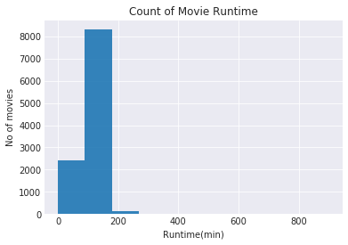

```python
#Let me see the number of movies and their runtime in a histogram
df.runtime.hist(alpha=0.9)
plt.title("Count of Movie Runtime") #set title
plt.xlabel("Runtime(min)") #set x-label
plt.ylabel("No of movies") #set y-label
plt.show()
```

Most of the movies have runtime >100 and <200

Now, does the length of the movie affect its profitablity?

Let me prepare a sactter plot to compare the two variables

```python
df3=df2[(df2.runtime >=100)] # create new dataframe
df4=df3[(df3.movie_income>0)] #just to remove zero profit movies for a clearer view
```

Then I will plot the both the regular and the zoom in

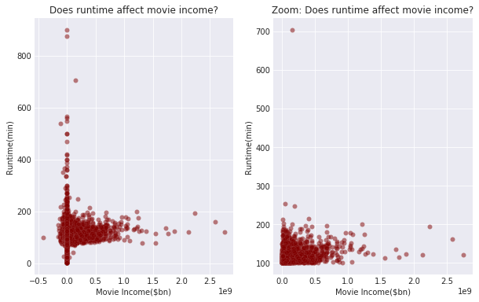

```python
xa = df2['movie_income']
ya = df2['runtime']
xb = df4['movie_income']
yb = df4['runtime']

fig, ax = plt.subplots(1,2, figsize=(10,6))
ax[0].set_title("Does runtime affect movie income?")
ax[0].set_xlabel("Movie Income($bn)")
ax[0].set_ylabel("Runtime(min)")

ax[1].set_title("Zoom: Does runtime affect movie income?")
ax[1].set_xlabel("Movie Income($bn)")
ax[1].set_ylabel("Runtime(min)")

ax[0].scatter(xa,ya, alpha=0.5, color='maroon', edgecolors='white', linewidths=0.1)
ax[1].scatter(xb,yb, alpha=0.5, color='maroon',edgecolors='white', linewidths=0.1)
plt.show()
```

The regular plot reconfirms most movie lengths are below 200minutes. It is hard to see a correlation

```python
df4['movie_income'].corr(df4['runtime']) #checking with Pearson coefficient
```

```
0.23040820595159775
```

The correlation is positive but low. Longer movies do not necessarily mean they would be profitable.

Furthermore, I can check with the popularity of the movies with respect to their runtime.

If runtime does not speak to profit, what does it speak to? And does this in turn speak to profit?

What length of movies are more popular: long or short?

Does popularity make a movie profitable? Let me visualize

[figure not shown]

```python
xc = df2['popularity']
yc = df2['runtime']
xd = df2['popularity']
yd = df2['movie_income']

#checking  runtime and popularity
fig, ax = plt.subplots(1,2, figsize=(10,6))
ax[0].set_title("Does runtime affect movie popularity?")
ax[0].set_xlabel('Popularity')
ax[0].set_ylabel("Runtime(min)")

#popularity of the movies with respect to their income.
ax[1].set_title('Are popular movies more profitable?')
ax[1].set_xlabel('Popularity')
ax[1].set_ylabel('Movie Income($bn)')

ax[0].scatter(xa,ya, alpha=0.5, color='green', edgecolors='white', linewidths=0.1)
ax[1].scatter(xb,yb, alpha=0.5, color='green',edgecolors='white', linewidths=0.1)
plt.show()
```

```python
df2['movie_income'].corr(df2['popularity'])
```

```
0.5627965618029979
```

A positive correlation confirms they increase in same direction. And 0.56 is tending towards +1 fairly

### Research Question 2 (Do movies with better more user engagement mean more income)

I would need to grouby genre, but this can only work if I split the strings contained as there are more than one genre for a movie and are separated with (|)

```python
#split genre and view
df5=df2.assign(genres=df2.genres.str.split('|')).explode('genres')
df5.head()
```

|  | id | popularity | runtime | genres | release_date | vote_count | vote_average | release_year | budget | revenue | movie_income | release_day |
| --- | --- | --- | --- | --- | --- | --- | --- | --- | --- | --- | --- | --- |
| 0 | 135397 | 32.985763 | 124 | Action | 2015-06-09 | 5562 | 6.5 | 2015 | 1.379999e+08 | 1.392446e+09 | 1.254446e+09 | Tuesday |
| 0 | 135397 | 32.985763 | 124 | Adventure | 2015-06-09 | 5562 | 6.5 | 2015 | 1.379999e+08 | 1.392446e+09 | 1.254446e+09 | Tuesday |
| 0 | 135397 | 32.985763 | 124 | Science Fiction | 2015-06-09 | 5562 | 6.5 | 2015 | 1.379999e+08 | 1.392446e+09 | 1.254446e+09 | Tuesday |
| 0 | 135397 | 32.985763 | 124 | Thriller | 2015-06-09 | 5562 | 6.5 | 2015 | 1.379999e+08 | 1.392446e+09 | 1.254446e+09 | Tuesday |
| 1 | 76341 | 28.419936 | 120 | Action | 2015-05-13 | 6185 | 7.1 | 2015 | 1.379999e+08 | 3.481613e+08 | 2.101614e+08 | Wednesday |

Let me first see what genre was produced the most and then see if these genres have good user engagement

```python
df5a =df5.groupby(['genres'])['genres'].count().sort_values(ascending=False)
df5a.head()
```

```
genres
Drama       4751
Comedy      3782
Thriller    2905
Action      2382
Romance     1705
Name: genres, dtype: int64
```

Drama, Comedy and Thriller are the most produced. Action follows behind.

I will be measuring user engagement by popularity and votes. Now let me see if Drama, Comedy and Thriller have good engagement

**BECAUSE I WILL BE USING THE GROUPBY FUNCTION (MEAN) REPEATEDLY, LET ME DEFINE IT FOR REUSE**

```python
def group_view():
    data = source.groupby([x])[y].mean().sort_values(ascending=False)
    return data

#First, I will group by avaerage popularity by genres
source=df5
x='genres'
y='popularity'
group_view()
```

```
genres
Adventure          1.153768
Science Fiction    1.002023
Fantasy            0.991874
Action             0.926235
Animation          0.852182
Family             0.787579
Crime              0.745410
Thriller           0.741917
War                0.727683
Mystery            0.691659
Romance            0.594030
Comedy             0.593997
Drama              0.592374
Western            0.590615
History            0.575936
Music              0.493940
Horror             0.466995
TV Movie           0.273758
Foreign            0.192147
Documentary        0.181698
not_given          0.171879
Name: popularity, dtype: float64
```

Oops! Adventure, Science Fiction, Fantasy, and Action are the tops

Well, perhaps they have good votes even though they are not popular

So let me check votes for each genre

```python
#Viewer votes for each genre
source=df5
x='genres'
y='vote_average'
group_view()
```

```
genres
Documentary        6.915280
Music              6.484289
not_given          6.450000
History            6.410479
Animation          6.403147
War                6.297778
Drama              6.165839
Crime              6.125351
Western            6.083030
Romance            6.045044
Family             5.999186
Foreign            5.982888
Mystery            5.951485
Adventure          5.940952
Comedy             5.905579
Fantasy            5.864044
TV Movie           5.797561
Action             5.787951
Thriller           5.751979
Science Fiction    5.666694
Horror             5.340270
Name: vote_average, dtype: float64
```

It's hard to say. The votes for each genre are quite close. Recall that the standard deviation for votes is even less than 1

I think most voters on IMDB may not even watch before voting. Probably just read the overview and the click to vote

```python
#Voters per genre group
source=df5
x='genres'
y='vote_average'
df9 =group_view()
```

[figure not shown]

```python
#Plot to view the voters per genre
x9=df9.index
y9=df9.values
title9=('Voters per genre')
x9label=('voters')
y9label=('genres')
plt.barh(x9, y9, alpha=0.5, color='maroon')
plt.title(title9, size=16)
plt.xlabel(x9label)
plt.ylabel(y9label)
plt.show()
```

Now, are these movies that are popular with users released on certain days? Perhaps, on days that we can go to the cinemas I will group genres by release day

```python
# group genres by release day
df10=(df5.groupby(['genres'])['release_day'].value_counts()).to_frame() #counts the number of movies in that day
df10.rename(columns={'release_day':"count_of_movies"})
df10.head()
```

| genres | release_day | release_day |
| --- | --- | --- |
| Action | Friday | 879 |
|  | Thursday | 441 |
|  | Wednesday | 339 |
|  | Tuesday | 333 |
|  | Monday | 145 |

I will make a vertical barplot to see this clearly

```python
x=df10.index
y=df10.values
df10.unstack('release_day').plot.bar(figsize=(18,5))
plt.title('Daily Movie Genre Release')
plt.xlabel('genres')
plt.ylabel('no of movies')
plt.show()
```

[output not shown]

I can see that most releases were on Fridays for all genres. Makes sense, Fridays are for movie nights, lol.

So this rules out my 'release_day' theory

So far, I have gathered that the most produced genre are: (Drama, Comedy, Thriller, Action)

And the most popular amongst viewers are: (Adventure, SciFi, Fantasy, Action)

**So which ones are most profitable? Lets dive in! I will create a dataframe of movies with the genres in question**

```python
#A dataframe of the select genres
df11 = df5.loc[df['genres'].isin(['Drama', 'Comedy', 'Thriller','Action','Adventure', 'Science Fiction', 'Fantasy'])]
#let me confirm if this has been done
df11.genres.unique()
```

[output not shown]

```python
#Now let me try to compare the genres and the income using a violinplot
```

```python
a=df11['genres']
b=df11['movie_income']
plt.figure(figsize=(10,7))
sns.set_style('whitegrid')
sns.stripplot(a,b)
sns.violinplot(a,b)
plt.title('Income from movie genres')
```

[output not shown]

For clarity, I will prepare a dataframe that has the total income and average income of each genre

To do this, I will:

Group total income by genre

Then group average income by genre

And merge them

```python
#Group total income by genre
df12=df11.groupby(['genres'],as_index=False)['movie_income'].sum()
df12
```

[output not shown]

```python
#Group average income by genre
df13=df11.groupby(['genres'],as_index=False)['movie_income'].mean()
df13
```

[output not shown]

```python
#merge them
pd.merge(df12,df13,on='genres')
```

[output not shown]

## Conclusions

> **Do movies with better more user engagement mean more income?**

**a.What genre are these movies?**

Most produced genre(Drama, Comedy, Thriller, Action),

Most popular amongst viewers: (Adventure, SciFi, Fantasy, Action)

**b.The day which the movie is released (weekend or weekday) could also affect user engagement**

Most movies are released on Friday. This was observed across the genres

> **Limitations** More than half of this dataset has income calculation as zero. My analysis was based on this error as the rows were too many to drop

```python
from subprocess import call
call(['python', '-m', 'nbconvert', 'Investigate_a_Dataset.ipynb'])
```